# 正準相関分析の例

- ２つの変数群に共通の隠れ変数群を見つける
- https://cmdlinetips.com/2020/12/canonical-correlation-analysis-in-python/ より

```python
import pandas as pd
import matplotlib.pyplot as plt
import seaborn as sns
import numpy as np
```

```python
link2data = "https://raw.githubusercontent.com/mwaskom/seaborn-data/master/penguins.csv"
df = pd.read_csv(link2data)
df = df.dropna()
df.head()
```

|  | species | island | bill_length_mm | bill_depth_mm | flipper_length_mm | body_mass_g | sex |
| --- | --- | --- | --- | --- | --- | --- | --- |
| 0 | Adelie | Torgersen | 39.1 | 18.7 | 181.0 | 3750.0 | MALE |
| 1 | Adelie | Torgersen | 39.5 | 17.4 | 186.0 | 3800.0 | FEMALE |
| 2 | Adelie | Torgersen | 40.3 | 18.0 | 195.0 | 3250.0 | FEMALE |
| 4 | Adelie | Torgersen | 36.7 | 19.3 | 193.0 | 3450.0 | FEMALE |
| 5 | Adelie | Torgersen | 39.3 | 20.6 | 190.0 | 3650.0 | MALE |

```python
df.shape
```

```
(333, 7)
```

- 上記データセットを２つの変数群(bill* と fipper & body_)に分ける

```python
x = df[['bill_length_mm', 'bill_depth_mm']]
x.head(3)
```

|  | bill_length_mm | bill_depth_mm |
| --- | --- | --- |
| 0 | 39.1 | 18.7 |
| 1 | 39.5 | 17.4 |
| 2 | 40.3 | 18.0 |

```python
y = df[['flipper_length_mm', 'body_mass_g']]
y.head(3)
```

|  | flipper_length_mm | body_mass_g |
| --- | --- | --- |
| 0 | 181.0 | 3750.0 |
| 1 | 186.0 | 3800.0 |
| 2 | 195.0 | 3250.0 |

- どちらも標準化する

```python
x_mc = (x - x.mean()) / (x.std())
x_mc.head(3)
```

|  | bill_length_mm | bill_depth_mm |
| --- | --- | --- |
| 0 | -0.894695 | 0.779559 |
| 1 | -0.821552 | 0.119404 |
| 2 | -0.675264 | 0.424091 |

```python
y_mc = (y - y.mean()) / (y.std())
y_mc.head(3)
```

|  | flipper_length_mm | body_mass_g |
| --- | --- | --- |
| 0 | -1.424608 | -0.567621 |
| 1 | -1.067867 | -0.505525 |
| 2 | -0.425733 | -1.188572 |

- 身長、体重、羽の長さなどは当然、ペンギンの種類により異なる
- なので、この２つのデータセットに共通の隠れ変数は、種類と考えられる

### sklearnにより、正準相関係数と正準相関変数を求める

- 固有値の数だけ、正準相関係数と正準相関変数がある（第一正準相関変数、第二正準相関変数・・・）

```python
from sklearn.cross_decomposition import CCA
```

```python
ca = CCA()
ca.fit(x_mc, y_mc)
x_c, y_c = ca.transform(x_mc, y_mc)
```

```python
x_c[:3]
```

[output not shown]

```python
y_c[:3]
```

```
array([[-1.40879506,  0.68286617],
       [-1.05385671,  0.42987851],
       [-0.3935502 , -0.83961988]])
```

```python
print(x_c.shape)
print(y_c.shape)
```

```
(333, 2)
(333, 2)
```

- x_c、y_cはそれぞれ、正準相関により射影された各データ

## 正準相関分析結果の理解

- 正準相関分析により射影した結果をDF化

```python
cc_res = pd.DataFrame({"Ccx_1": x_c[:,0],
                       "Ccy_1": y_c[:,0],
                       "Ccx_2": x_c[:,1],
                       "Ccy_2": y_c[:,1],
                       "Species": df.species.to_list(),
                       "Island": df.island.to_list(),
                       "Sex": df.sex.to_list()})
cc_res.head()
```

|  | Ccx_1 | Ccy_1 | Ccx_2 | Ccy_2 | Species | Island | Sex |
| --- | --- | --- | --- | --- | --- | --- | --- |
| 0 | -1.186252 | -1.408795 | -0.010367 | 0.682866 | Adelie | Torgersen | MALE |
| 1 | -0.709573 | -1.053857 | -0.456036 | 0.429879 | Adelie | Torgersen | FEMALE |
| 2 | -0.790732 | -0.393550 | -0.130809 | -0.839620 | Adelie | Torgersen | FEMALE |
| 3 | -1.718663 | -0.542888 | -0.073623 | -0.458571 | Adelie | Torgersen | FEMALE |
| 4 | -1.772295 | -0.763548 | 0.736248 | -0.014204 | Adelie | Torgersen | MALE |

- 一番目の正準相関変数同士（Ccx_1 , Ccy_1）の相関を求める

```python
np.corrcoef(x_c[:,0], y_c[:,0])
```

```
array([[1.        , 0.78763151],
       [0.78763151, 1.        ]])
```

- 二番目の正準相関変数同士（Ccx_2 , Ccy_2）の相関を求める

```python
np.corrcoef(x_c[:,1], y_c[:,1])
```

```
array([[1.        , 0.08638695],
       [0.08638695, 1.        ]])
```

- Ccx_1とCcy_1をプロットして相関具合を確認

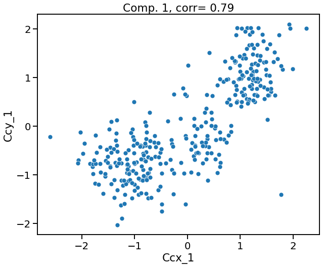

```python
sns.set_context("talk", font_scale=1.2)
plt.figure(figsize=(10,8))
sns.scatterplot(x="Ccx_1", y="Ccy_1", data=cc_res)
plt.title("Comp. 1, corr= %.2f" % np.corrcoef(x_c[:,0], y_c[:,0])[0,1])
```

## 隠れ変数であるSpecies(種類)と第一の相関変数群の相関具合を確認する

- 隠れ変数Speciesと各第一相関変数(Ccx_1とCcy_1)の関係をboxplotで可視化

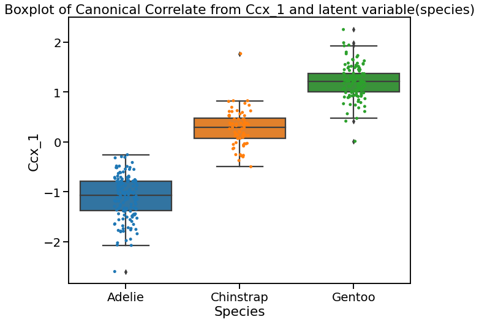

```python
plt.figure(figsize=(10,8))
plt.title('Boxplot of Canonical Correlate from Ccx_1 and latent variable(species)')
sns.boxplot(x="Species", y="Ccx_1", data=cc_res)
sns.stripplot(x="Species", y="Ccx_1", data=cc_res)
```

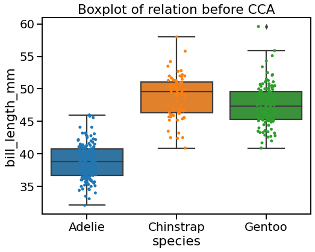

```python
plt.figure(figsize=(8,6))
plt.title('Boxplot of relation before CCA')
sns.boxplot(x="species", y="bill_length_mm", data=df)
sns.stripplot(x="species", y="bill_length_mm", data=df)
```

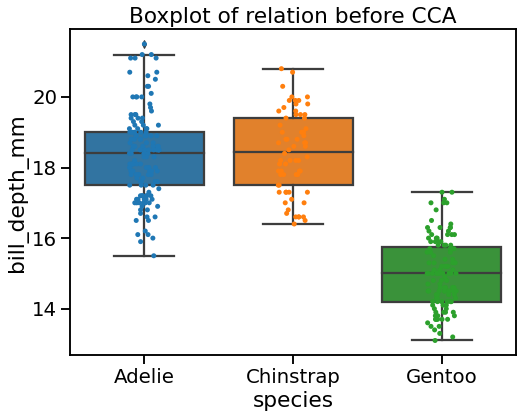

```python
plt.figure(figsize=(8,6))
plt.title('Boxplot of relation before CCA')
sns.boxplot(x="species", y="bill_depth_mm", data=df)
sns.stripplot(x="species", y="bill_depth_mm", data=df)
```

- **CCA前では、bill_length_mm変数と、bill_depth_mm変数それぞれ、speciesの特徴を捉えていないが、CCAを行うことで、新変数Ccx_1がspeciesの特徴をとらえている**

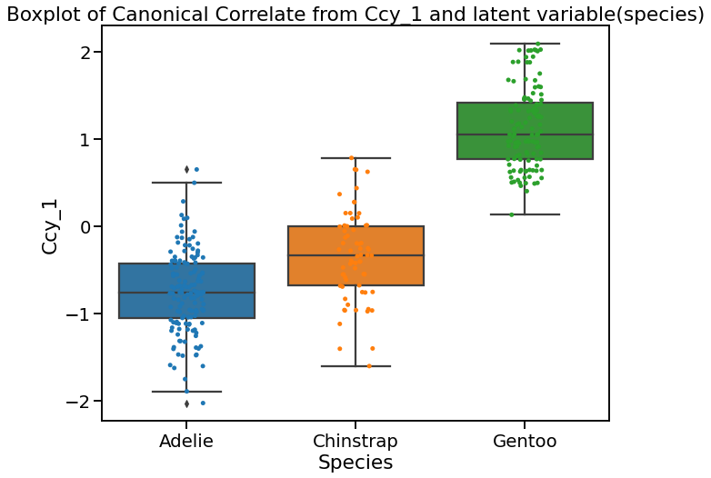

```python
plt.figure(figsize=(10,8))
plt.title('Boxplot of Canonical Correlate from Ccy_1 and latent variable(species)')
sns.boxplot(x="Species", y="Ccy_1", data=cc_res)
sns.stripplot(x="Species", y="Ccy_1", data=cc_res)
```

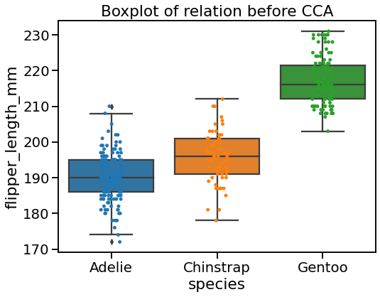

```python
plt.figure(figsize=(8,6))
plt.title('Boxplot of relation before CCA')
sns.boxplot(x="species", y="flipper_length_mm", data=df)
sns.stripplot(x="species", y="flipper_length_mm", data=df)
```

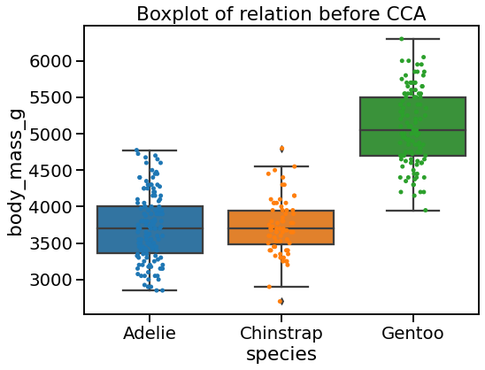

```python
plt.figure(figsize=(8,6))
plt.title('Boxplot of relation before CCA')
sns.boxplot(x="species", y="body_mass_g", data=df)
sns.stripplot(x="species", y="body_mass_g", data=df)
```

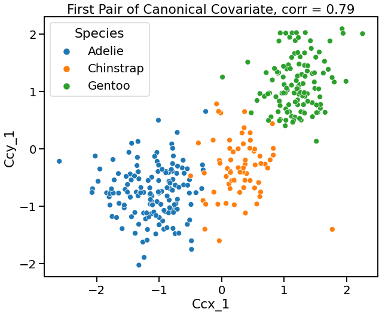

```python
plt.figure(figsize=(10,8))
sns.scatterplot(x="Ccx_1", y="Ccy_1", hue="Species", data=cc_res)
plt.title('First Pair of Canonical Covariate, corr = %.2f' % np.corrcoef(x_c[:,0], y_c[:,0])[0,1])
```

- **それぞれの第一相関変数同士は、相関関係を持ちつつ、共通の隠れ変数(species)の特徴を捉えている**

## 第一相関変数、第二相関変数とオリジナルの変数の相関具合をヒートマップで確認

```python
ccX_df = pd.DataFrame({"CCX_1":x_c[:, 0],
                       "CCX_2":x_c[:, 1],
                       "Species":df.species.astype('category').cat.codes,
                      "Island":df.island.astype('category').cat.codes,
                      "sex":df.sex.astype('category').cat.codes,
                       "bill_length":x_mc.bill_length_mm,
                      "bill_depth":x_mc.bill_depth_mm})
```

```python
corr_X_df= ccX_df.corr(method='pearson')
corr_X_df.head()
```

|  | CCX_1 | CCX_2 | Species | Island | sex | bill_length | bill_depth |
| --- | --- | --- | --- | --- | --- | --- | --- |
| CCX_1 | 1.000000e+00 | 7.728804e-18 | 0.935057 | -0.561781 | 0.025383 | 0.828437 | -0.734650 |
| CCX_2 | 7.728804e-18 | 1.000000e+00 | -0.078719 | 0.228933 | 0.576790 | 0.560082 | 0.678447 |
| Species | 9.350575e-01 | -7.871884e-02 | 1.000000 | -0.622428 | 0.010964 | 0.730548 | -0.740346 |
| Island | -5.617810e-01 | 2.289327e-01 | -0.622428 | 1.000000 | -0.012435 | -0.337179 | 0.568031 |
| sex | 2.538332e-02 | 5.767897e-01 | 0.010964 | -0.012435 | 1.000000 | 0.344078 | 0.372673 |

```python
plt.figure(figsize=(10,8))
X_df_lt = corr_X_df.where(np.tril(np.ones(corr_X_df.shape)).astype(np.bool))
```

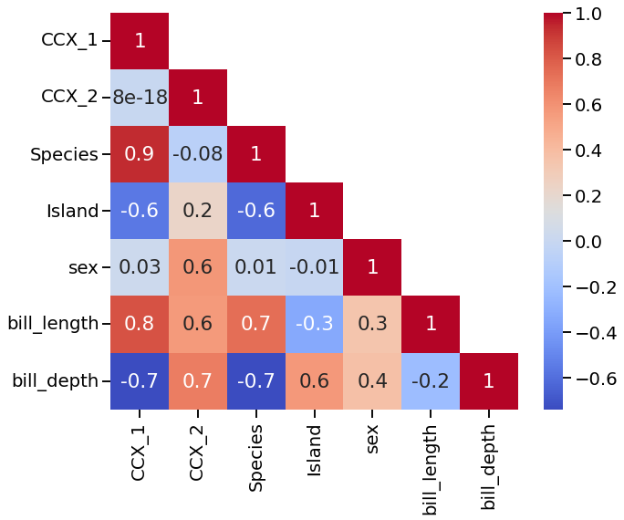

```python
plt.figure(figsize=(10,8))
sns.heatmap(X_df_lt,cmap="coolwarm",annot=True,fmt='.1g')
```

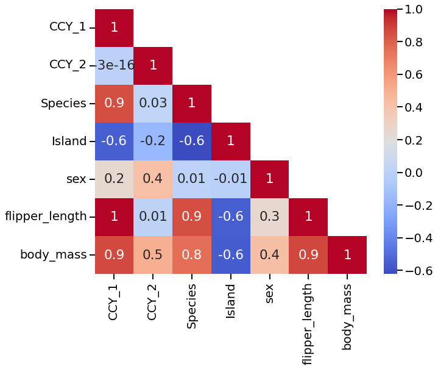

```python
# second pair of canonical covariates with the dataset
ccY_df = pd.DataFrame({"CCY_1":y_c[:, 0],
                       "CCY_2":y_c[:, 1],
                       "Species":df.species.astype('category').cat.codes,
                      "Island":df.island.astype('category').cat.codes,
                      "sex":df.sex.astype('category').cat.codes,
                       "flipper_length":y_mc.flipper_length_mm,
                      "body_mass":y_mc.body_mass_g})
# compute correlation with Pandas corr()
corr_Y_df= ccY_df.corr(method='pearson')
# Get lower triangular correlation matrix
Y_df_lt = corr_Y_df.where(np.tril(np.ones(corr_Y_df.shape)).astype(np.bool))
# make a lower triangular correlation heatmap with Seaborn
plt.figure(figsize=(10,8))
sns.heatmap(Y_df_lt,cmap="coolwarm",annot=True,fmt='.1g')
```

- ccx_1, ccy_1ともに、Speciesとの相関が高い
- ccx_2, ccy_2ともに、sexとの相関が高い
- よって、この２つの変数群(['bill_length_mm', 'bill_depth_mm']と['flipper_length_mm', 'body_mass_g'])それぞれに共通に影響を与えている因子として、Speciesとsexが働いていることがわかる